# Tool-driven Revolutions in Archaeological Science

Sophie C. Schmidt

Ben Marwick

10 September, 2018

Abstract

There is an argument in philosophy of science that revolutions in science are either ideas-driven or tool-driven. We explore this debate in light of recent efforts by many scientific disciplines to embrace methods to improve the reproducibility of their research. One of the most profound changes driven by this concern for reproducibility and transparency is from analysing data using tools dependent on pointing-and-clicking with a mouse in commercial software, to a new set of tools based on writing scripts in free and open source programming languages. We review bibliometric evidence for this change in the sciences generally and in archaeology in particular to test if the adoption of these new tools may be considered a revolution or some other process. We evaluate how computational approaches to improving reproducibility and transparency in archaeology are mediated and transformed by digital approaches.

# Introduction

In this paper we investigate recent changes in the way computational archaeology is being done. Revolutions or paradigm-shifts in archaeology have been discussed to happen following theoretical discurses(Clark 1993; Härke 2002), but there has been an argument in philosophy of science whether revolutions in science are either ideas-driven or tool-driven (Galison 1997; Dyson 2000). In this light we explore how many scientific disciplines have started to embrace methods to improve the reproducibility of their research and whether this change is part of a paradigm-shift. We focus on one set of tools for this change which is based on writing scripts in free and open source programming languages and review bibliometric evidence for this change in the sciences generally and in archaeology in particular. We evaluate how computational approaches to improving reproducibility and transparency in archaeology are mediated and transformed by digital approaches and test if the adoption of these new tools may be considered a revolution or some other process.

# Revolutions in Science: Ideas-driven or Tool-driven?

There is an argument among philosophers of science that revolutions in science are either ideas-driven or tool-driven. One of the most widely-known models of ideas-driven change in science is Kuhn’s (1962) effort to describe the history of science by proposing paradigm shifts resulting from revolutionary change in communities of researchers. In brief, this model proposes that the history of science consists of long periods of tradition-bound ‘normal science’ punctuated by short episodes of revolution. Normal science was described by Kuhn as stagnant, routine day-to-day research focused on ‘puzzle solving’. What counts as suitable puzzles, and acceptable solutions to these puzzles, is governed by the norms and procedures of the prevailing paradigm. Revolutions in science occur as punctuations in the equilibria of normal science, when anomalous observations culminate in changes that replace one paradigm with another in a conversion or speciation process where the community adopts a new way of doing science. There has been substantial debate about how to draw a clear distinction between so-called normal and revolutionary science. (Watkins 1970; Toulmin 1970; Casadevall and Fang 2016). A notable criticism is that Kuhn’s normal science is unscientific, a situation where critical science had contracted into defensive metaphysics resulting from the domination of a ruling dogma (Popper 1970). This is at odds with a view of science that it is in a continuous state of revolution, with researchers simultaneously employing several styles of thinking and doing science, and continuously confronting theory with evidence and modifying their ideas based on the outcome. In this view, based on the post-World War II era of science, radical discontinuities are rare, and major developments instead emerge from the division and recombination of already mature fields (Andersen 2013). Given the rarity of radical discontinuities, some biologists have argued that change in biology is better characterised by new ideas (e.g. Mendelian heredity, Darwinian evolution, and molecular genetics) replacing not a former paradigm but a conceptual vacuum (Wilkins 1996).

In archaeology we have seen claims for paradigm shifts in several areas. The most wide-ranging application is Clark’s (1993) comparison of North American archaeology to European archaeology during the 1970s-90s. Clark, similar to Binford and Sabloff (1982), identified the North American archaeological paradigm as rooted in anthropology, founded on post-positivist biases, and distinctive with it critical-realist ontology, a modified-objectivist epistemology, and an experimental-manipulative methodology. In contrast, the European archaeological paradigm is described a kind of history, mostly in a strict empiricist tradition, and typified by a realist ontology, an inductivist epistemology, and by an observational methodology. Clark’s analysis describes a multi-paradigm situation where multiple research communities (i.e. North American and European) simutaneously operate in different paradigms (which Kuhn noted as a sign of a developing or immature discipline). His account is not a complete Kuhnian analysis because it lacks a revolutionary change event where one paradigm is replaced by another, although he hints that processual archaeology may be considered a radical discontinuity relative to the culture-historical approaches that preceeded it (Clark 1993, 206).

A more thorough treatment of the claim that processual archaeology was a paradigm shift is provided by Meltzer (1979). Meltzer reviews literature arguing for a revolutionary change in archaeology during the 1960s and 1970s, and considers these claims in light of classic Kuhnian revolutionary events such as the replacement of the Ptolemaic system by the Copernican system, and Newtonian dynamics by the new Einsteinian dynamics. He finds that the changes that occured in Anglophone archaeology after the 1960s were incremental, and primarily of method, rather than a widespread replacement of one ontological structure by another one, incommensurable or incompatible with the former. Trigger (2006, 538) came to a similar conclusion at the end of his broad survey of the history of archaeology, that changes throughout archaeology have been mostly additive with only partial replacement.

We see less formal mentions of paradigm shifts in archaeology in reference to processual to post-processual archaeology (Härke 2002), as well as more localised and specific shifts in archaeological practice and thinking. For example, Snodgrass (2002) claims that among Classical Archaeologists, an increase in research on previously neglected periods odf antiquity, such as the Greek Early Iron Age, constitutes a paradigm shift. McAnany and Rowe (2015) propose that the appearance of community-based participatory models of research among some communities of archaeologists is a paradigm shift, though they concede that it is more transformational rather than revolutionary. Fuller (2010) has used the term to describe a shift in thinking about the emergence of agriculture as a parallel, simultaneous event at the start of the Holocene (the Neolithic Revolution), to new concept of the emergence as a protracted and entangled process, happening 20 or so times independently, following different pathways. Most of these paradigms are quite remote in meaning from Kuhn’s classical formulation, and this highlights an important complication with using Kuhn’s paradigm shift approach, both as a tool to understand the history of science and as a guide to changing it, which is Kuhn’s multiple definitions of a paradigm.

Masterman (1970) has documented 21 different uses by Kuhn, which she organises into three groups. First is the metaphysical notion of a set of beliefs, and this is the sense that dominates most of the critical writing on Kuhn’s model. Second is the sociological sense of scientific habits, the universially recognised scientific achievements that are the foundations of day-to-day normal science. These include specific attention-grabbing successes that provide a touchstone for the coordination of future research. Third is the concrete sense of an actual textbook, instrumentation or toolkit. This recognition of the multivalent nature of paradigms is important because it broadens the locus for scientific revolution to include sociological practices of science, such as might be produced by changes in norms of publication and peer review, and to include the physical infrastructure of doing science, such as the technology for collecting and analysing data, and for communication and collaboration among researchers.

Galison’s emphasis on tool-driven change, as a complement to Kuhnian concept-driven change, has much potential for archaeology. The centrality of material culture in Galison’s view raises the question about whether there is scope for archaeologists to make productive contributions to understanding change in the history science through an archaeological analysis of scientific instrumentation (cf. Schiffer 2013). Furthermore, Galison’s analysis of the image/logic contrast in the history of physics invites a similar analysis of the history of archaeology Can we identify archaeological traditions focused on data collection and analysis using images and image-making devices (cf. Molyneaux 2013), in contrast to digital devices? One candidate for this might be the shift from building relative chronologies based on seriation of visually distinctive artefacts to absolute chronologies based on radiometric dating using computer-controlled instruments. A third issue is how we can use a tool-driven approach not just as a framework for understanding change in science, but as a method to predict or generate change in archaeology?

# Bibliometric analysis of tool-driven change

The question of predicting or generating change in scientific practice via adoption of new tools is especially intruiging, and in this section we explore how a change that has been observed in ecology might be relevant for understanding or even directing the future of archaeology.

## Looking back on a tool-driven change in Ecology

Touchon and McCoy (2016) investigated evaluated changes in statistics used by ecologists as a potential area of tool-driven change. They searched nearly 20,000 published articles in ecology published between 1990 and 2013. They found that there has been a rise in complex and computationally intensive statistical techniques such as mixed effects models and Bayesian statistics and a decline in reliance on approaches such as ANOVA or t-tests. Crucially, they found that ecologists have shifted away from software tools such as SAS and SPSS to the open source program R.

Touchon and McCoy (2016) identify four factors relating to technological change that might explain the changes they observed in the use of statistics in ecology. First, they note that automated data loggers, GPS trackers, remote sensing, and crowd sourcing have greatly increased rate at which ecologists collect data. Second, increases in desktop and cluster computing power has made complex analytical processes faster and more convienent to compute. Third, the development of free, open source and easily extensible software for data analysis and visualisation, such as R, allows new methods to spread quickly via online fora and social media. Fourth, the publication of several books and papers that have strongly influenced the way many ecologists think about data analysis, such as Burnham and Anderson (2003)’s book on model selection and inference.

While all of these four factors could be considered relevant to the tooling of ecology and archaeology, we focus here on the third one because of its relevance to archaeology. Archaeology and ecology each have a high diversity of data collection methods, and types of data analyses they conduct, with only a small overlap. What they share in common is working with the field-collected data on a computer to prepare it for publication. R is the most common open source and free ware data analysis tool available and therefore a good proxy for the adoption of open source scientific programming languages in a discipline. To investigate changes in the use of R in archaeology and ecology, we obtained reference lists from a sample of scholarly articles in the Web of Science database and examined patterns in the citation of the R program over time.

We used the ‘Cited Reference Search’ function provided by the Web of Science online scientific citation indexing service to identify journal articles that cite R. Although R has been available since the late 1990s (Thieme 2018), a recommended format for citing the software did not appear until 2004, with the author given as “R Development Core Team”. This recommended format for citing the software changed slightly in 2012 when the author was updated to “R Core Team”. We searched the Web of Science using ‘“R DEV COR TEAM” OR “R CORE” OR “R CORE TEAM” OR “R DEVELOPMENT CORE TEAM”’ in the CITED AUTHOR field. We sorted the results by frequency of citation, and selected the first 1000 items (the maximum allowed by the Web of Science service). These 1000 items represent variations on the recommended format for citing R, and found in the reference lists of 33,326 English-languge articles indexed by the Web of Science in the research area of Environmental Sciences Ecology. We then downloaded the bibliographic data for all of these articles.

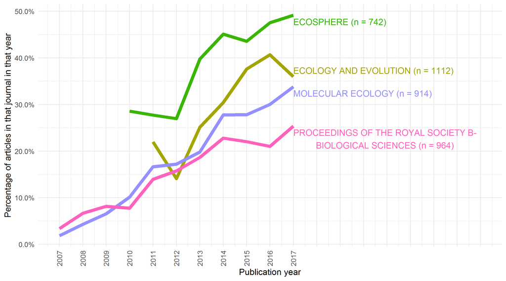

## Looking forward to a tool-driven change in Archaeology

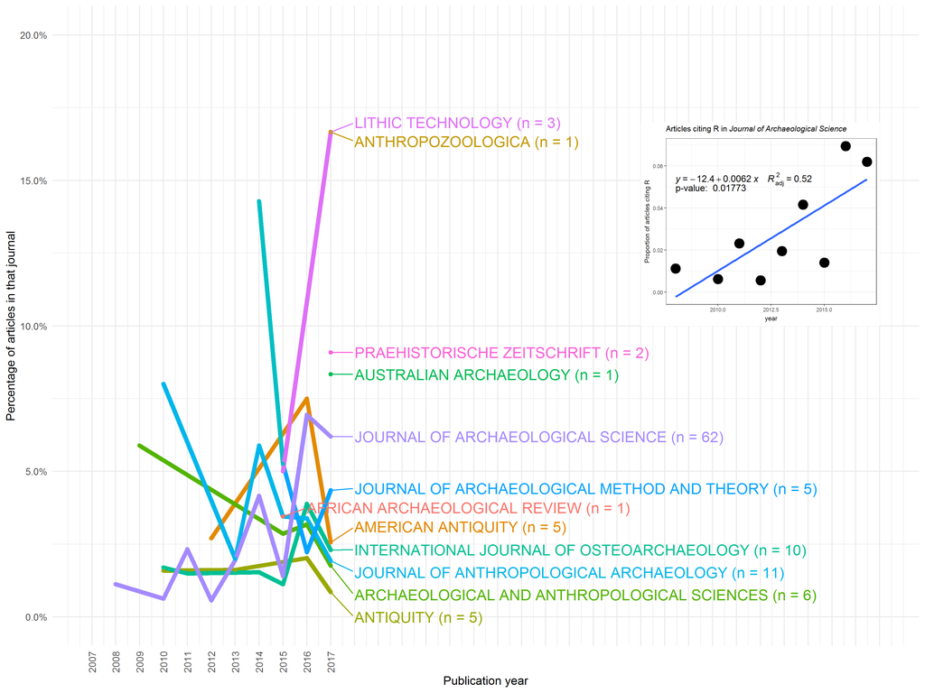

## What are R-using archaeologists writing about?

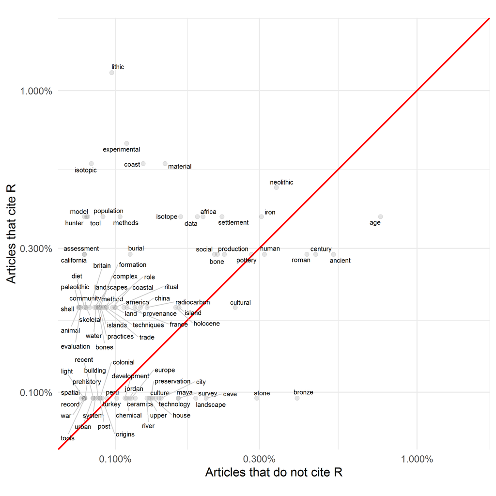

Figure 3: Comparing the frequency of words used in titles of archaeology articles (41,236 words in 42,451 articles)

Figure 3 supports our initial observations that archaeologists using R tend to be doing archaeology that involves the natural and physical sciences. Articles that cite R more often have titles that include terms such as ‘lithic’, ‘experimental’, and ‘isotope’. On the other hand, articles that do not cite R more often discuss the Roman and Bronze Age periods, and less often reflect a technical specialisation, if there is one, it seems to be in ceramics.

## From using code in research to sharing code with publications

In our view, merely using R (or similar open source programming languages) to conduct research might not constitute a tool-driven revolutionb by itself, but publicaly sharing the code used for research, as a solution to problems of irreproducibility, could enable revolutionary change. Openly shared code could speed the widespread adoption of the reproducibility are a core tenet of the scientific process, since it frees researchers from the black box that most mouse-driven computers are, and enables researchers to not only rerun the shared analysis, but to gain access to all parameter settings, empowering them to change these and therefore properly evaluate, extend and reuse the published results. As open source languages such as R (or Python…) are free to use, and most trustworthy repositories are also free (such as zenodo, osf, figshare, etc.), then even researchers with limited resources anywhere in the world can to contribute equally to the research community by using and sharing code.

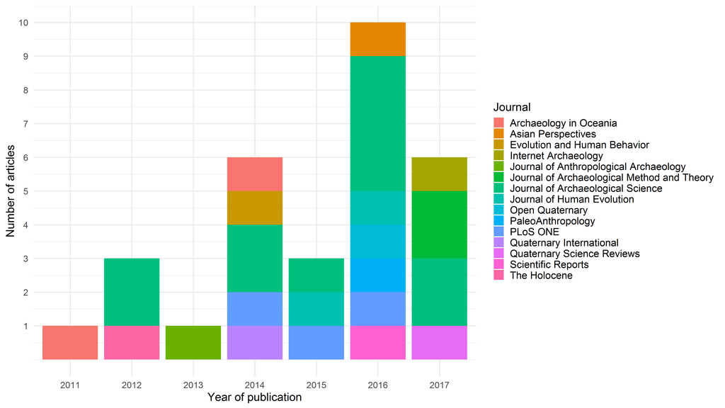

A pragamtic issue relating to wide-spread changes in scientific practice is what the incentives are for members of the research community. This is especially a concern for researchers that might not be motivated by a desire to adhere to the abstract basic principles of what it means to practice science with integrity. If code sharing has some concrete career advantages then we might expect it to be more likely to be part of a tool-drive revolution. Vandewalle (2012) analysed citation rates for 645 articles published in *IEEE Transactions on Image Processing* during 2004–2006. He found statistically significant differences between the median number of citations for papers that have code available and papers that do not have code available. In Figure 5 we conducted a similar anlysis for archaeology articles using the ‘TC’ field in the data we obtained from the Web of Science service. TC stands for ‘Web of Science Core Collection Times Cited Count’. This Times Cited count displays the total number of times a published paper was cited by other papers within the Web of Science Core Collection. Unlike Google Scholar, this does not include citations on blogs, pre-prints and other places outside of journal articles, so the citation counts from Web of Science are lower than those on Google Scholar. We see that archaeological articles that cite R are consistently more highly cited themselves than articles that do not cite R.

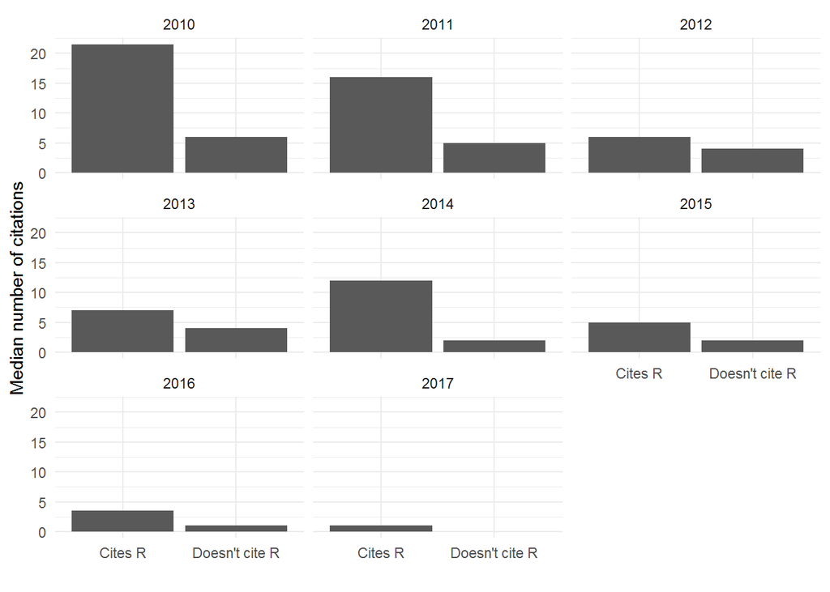

Figure 5: Median citation rates per year for archaeology articles that cite R (n = 116) and articles that do not cite R (n = 42,335)

# Discussion

In light of the discussion in the philosophy of science, whether paradigm-shifts are tool- or idea-driven, we offer the hypothesis that a tool-driven change of paradigms is underway in the biological sciences and, more subtly, in archaeology. The tool which drives this change is the use of scripting languages in computational approaches of these disciplines. We show that the use of R is on the rise among archaeologists using natural and physical science methods, and has concrete advantages for authors that publish papers that cite R as they tend to be referenced more often, giving the authors more visiblity and influence. This also is an indicator for the increase in popularity of R.

Rather, this change enables archaologists to more faithfully adhere to the fundamental tenet of the scientific process which demands the reproducibility of results. We do not want to claim archaeologists did not want to create reproducible research before the advance of scientific scripting languages. But instead that with the introduction of computers there has been a gradual and unintended drift away from reproducibility, and thus from scientific practice. By using and sharing code we can undo this drift, and return to a robust scrietific practice for archaeology.

There is a longstanding tradition in archaeology of publishing catalogues, lists and maps showing the data used for analyses. In the digital age, though, many archaeological tasks have shifted from the descriptive and qualitative aspects to quantitative and computational analyses. This shift also mandates a change in documentation of analyses to enable other researchers to reproduce published results. Modern archaeology has often been lacking in this aspect, as the research has been undertaken using point-and-click software, which obscures and complicates the reproducibility of analyses. As we show, the advance of scripting languages takes place mostly in the part of archaeology that is in close contact with natural and physical sciences. These sciences also show a trend to increased reproducibility as Journals change their data and code access policies, demanding code and data to be published alongside articles (Stodden, Guo, and Ma 2013).

We do not believe that a Kuhnian paradigm-change seems to be happening in ecology or archaeology: Data-and method sharing behaviour has been around in archaeology before and do not present incommensurate ways of thinking about the subject. What we can see, though, is that the need for methods to share research in a way that is reproducible for others has been acknowledged and that archaeologists have looked for tools to make this possible. Using scripting languages and data repositories to share the scripts is a solution that we have demonstrated enjoys increasing popularity in the archaeological research community.

## Making it easier

We acknowledge that learning to use code, if one has not recieved formal instruction, is not an easy task. As Papadopoulos, Chrysanthi, and Murietta-Flores (2012) illustrate, it requires a certain familiarity with the computational tools to be able to use them not just on a technological basis, but creatively and in full knowledge of their restrictions and ambiguities. The awareness and the appropriate handling of shortcomings and contexts of the data used in an analysis is also a time- and thought-consuming effort, which needs to stand at the beginning of each archaeological research (and which may be exacerbated by using multiple data sets from varying sources – see e. g. Huggett (2015)). We will not focus on data sharing here, though, but on the sharing of code.

As with data, sharing code in public takes a little time to ensure that it is fit for others to read. Our casual observations of the ways in which archaeologists are using and sharing code show a high degree of variability in code style and organisation, indicating that currently most archaeologists are independantly solving problems of how to write and share code through trial and error, rather than following a model or widely-used approach. This suggests to us that there is some scope to improve the ease and efficiency of code-use in archaeology by studying the exsiting practice and providing a model that others can easily adapt to their own research projects.

The result of our analysis of existing practices among archaeologists and other researchers, and our study of best practices in scientific computing (described in more detail in Marwick, Boettiger, and Mullen (2018)) is the R package rrtools (‘reproducible research tools’, https://github.com/benmarwick/rrtools). The goal of rrtools ist to make it easier for archaeologists and researchers in other fields to use R for research and publication. This package aims to simplify many of the steps needed to write reproducible research, and to guide users to best practices with minimal effort. The rrtools package contains functions that create a file structure according to fundamental principles of organising files for research. First, we keep the data separate from the methods. This means keep the code in a separate directory to the data. Second, we, keep the raw data seprate from data that is created or derived during the analysis.These two basic principles make it easy to stay organised during a complicated project, and make it easier for a reader to navigate their way through the compendium of files that are shared with the publication.

The rrtools package contains several functions for the R user to enable a researcher to quickly set up a compendium suitable for writing reproducible research in R. Each of these steps reflects a best practice that has been previously articulated in other feilds. We will focus here on the first five, as these are most relevant to most researchers:

- **rrtools::use_compendium:** This function creates a new directory for the research project, and creates an R package within this directory. We use the R package structure as the standard for our directory because it is widely recognised by R users. This means that people know where to look for code, where to look for data, and where to look for dependancies and other information.
- **usethis::use_mit_license:** This function creates a copy of the MIT software lisence to the compendium. This is important for two reasons. First, because it tells the reader that the author is happy for their code to be reused by other people. And second, it tells the reader that the author does not take responsibility for any problems that the reader might have when they use the code. This is important for setting the expectations about the relationship between the author and the reader, regarding the use of code.
- **usethis::use_github:** This will initiate the use of the Git version control system. This is the current state-of-the-art for version control of any kind of plain text file, including text, code, data, and images. This will also create a repository on the GitHub website. Using version control is important because it allows the author to time-travel back to earlier states of their analysis, if they take a dead-end path. It is also important for making collaboration smooth because many people can work on one set of files without losing track of what the most recent version is. Plus it is nice to have a remote back-up of our work in case of an emergency. The GitHub repository can be kept private if desired, until the work is published.
- **rrtools::use_readme_rmd:** This will create a simple document that is usually the first thing a reader sees when they browse the code files. This document is important because it helps to describe to the reader what to expect in the compendium, and it gives details of how to cite the compendium.
- **rrtools::use_analysis:** This function creates a set of folders according to the best practices for organising a typical reasearch project. We recognise that this file structure wont be perfect for every project. But we know that it will suit many projects quite well, and it will at least make the user think about how to organise their files logically, and according to best practises.

# Conclusion

We have shown a bibliometric analysis that reveals substantial change in the use of the R programming languages in ecology. We saw that ecological and evolutionary sciences have strongly embraced R in their publications. Archaeologists have more recently taken up R, but to a much lesser degree, so far, than what we see in the other fields, most commonly in more scientific aspects of archaeology. We also identified a small sub-set of archaeology papers that use R to make their work fully reproducible and could identify an advantage of citing R for researchers as it leads to being referenced more often.

There is great potential for archaeologists to make their work reproducible using R and related tools, and we think this is a much needed shift in computational archaeology - linking the digital and computational times to older practices of sharing data and methods. We therefore presented our freely available R package, rrtools, which is designed to make it easy for researchers in archaeology and other fields to make their research reproducible. We hope this will help to realise some of the potential to make computational archaeological research more open and reproducible speed the transfer of new results and methods throughout the research community without barriers due to resource availabilty, and in this way encourage researchers to adhere to the scientific process.

## Acknowledgements

Our project comes from the group who took part in the 2017 Summer School on Reproducible Research in Landscape Archaeology at the Freie Universität Berlin (17-21 July), funded and jointly organized by Excellence Cluster 264 Topoi, the Collaborative Research Center 1266, and ISAAKiel.

# References

Abari, Kálmán. 2012. “Reproducible Research in Speech Sciences.” *International Journal of Computer Science Issues* 9 (6):43–52. http://www.ijcsi.org/papers/IJCSI-9-6-2-43-52.pdf.

Andersen, Hanne. 2013. “The Second Essential Tension: On Tradition and Innovation in Interdisciplinary Research.” *Topoi* 32 (1). Springer:3–8.

Barnes, Nick. 2010. “Publish Your Computer Code: It Is Good Enough.” *Nature News* 467 (7317):753–53. https://doi.org/10.1038/467753a.

Baumer, Ben, Mine Cetinkaya-Rundel, Andrew Bray, Linda Loi, and Nicholas J. Horton. 2014. “R Markdown: Integrating a Reproducible Analysis Tool into Introductory Statistics.” *Technology Innovations in Statistics Education* 8 (1). http://www.escholarship.org/uc/item/90b2f5xh.

Binford, Lewis R, and Jeremy A Sabloff. 1982. “Paradigms, Systematics, and Archaeology.” *Journal of Anthropological Research* 38 (2). University of New Mexico:137–53.

Bray, Andrew, Mine Çetinkaya-Rundel, and Dalene Stangl. 2014. “Taking a Chance in the Classroom: Five Concrete Reasons Your Students Should Be Learning to Analyze Data in the Reproducible Paradigm.” *Chance* 27 (3):53–56. https://doi.org/10.1080/09332480.2014.965635.

Burnham, Kenneth P, and David R Anderson. 2003. *Model Selection and Multimodel Inference: A Practical Information-Theoretic Approach*. Springer Science & Business Media.

Casadevall, Arturo, and Ferric C. Fang. 2016. “Revolutionary Science.” *mBio* 7 (2). American Society for Microbiology. https://doi.org/10.1128/mBio.00158-16.

Clark, G. A. 1993. “Paradigms in Science and Archaeology.” *Journal of Archaeological Research* 1 (3):203–34. https://doi.org/10.1007/BF01326535.

Dyson, Freeman. 2000. *The Sun, the Genome, and the Internet*. New York Public Library Lectures in Humanities. Oxford University Press.

Dyson, Freeman J. 2012. “Is Science Mostly Driven by Ideas or by Tools?” *Science* 338 (6113). American Association for the Advancement of Science:1426–7.

Eglen, Stephen J. 2009. “A Quick Guide to Teaching R Programming to Computational Biology Students.” *PLoS Comput Biol* 5 (8):e1000482. https://doi.org/10.1371/journal.pcbi.1000482.

Fuller, Dorian Q. 2010. “An Emerging Paradigm Shift in the Origins of Agriculture.” *General Anthropology* 17 (2):1–12. https://doi.org/10.1111/j.1939-3466.2010.00010.x.

Galison, Peter. 1997. *Image and Logic: A Material Culture of Microphysics*. University of Chicago Press.

Härke, Heinrich. 2002. “Interdisciplinarity and the Archaeological Study of Death.” *Mortality* 7 (3):340–41. https://doi.org/10.1080/1357627021000025487.

Huggett, Jeremy. 2015. “2 Digital Haystacks: Open Data and the Transformation of Archaeological Knowledge.” In *Open Source Archaeology: Ethics and Practice*, edited by Andrew T. Wilson and Ben Edwards. Warsaw, Poland: De Gruyter Open. https://doi.org/10.1515/9783110440171-003.

Huvila, Isto, and Jeremy Huggett. 2018. “Archaeological Practices, Knowledge Work and Digitalisation.” *Journal of Computer Applications in Archaeology* 1 (1):88–100. https://doi.org/10.5334/jcaa.6.

Ince, Darrel C., Les Hatton, and John Graham-Cumming. 2012. “The Case for Open Computer Programs.” *Nature* 482 (7386):485–88. https://doi.org/10.1038/nature10836.

King, Gary. 1995. “Replication, Replication.” *PS: Political Science & Politics* 28 (03):444–52.

Kuhn, T. 1962. *The Structure of Scientific Revolutions*. University of Chicago Press.

LeVeque, Randall J., Ian M. Mitchell, and V. Stodden. 2012. “Reproducible Research for Scientific Computing: Tools and Strategies for Changing the Culture.” *Computing in Science & Engineering* 14 (4):13–17. https://doi.org/10.1109/MCSE.2012.38.

Markowetz, Florian. 2015. “Five Selfish Reasons to Work Reproducibly.” *Genome Biology* 16. BioMed Central.

Marwick, Ben, Carl Boettiger, and Lincoln Mullen. 2018. “Packaging Data Analytical Work Reproducibly Using R (and Friends).” *The American Statistician* 72 (1). Taylor & Francis:80–88.

Masterman, Margaret. 1970. “The Nature of a Paradigm.” In *Criticism and the Growth of Knowledge: Volume 4: Proceedings of the International Colloquium in the Philosophy of Science, London, 1965*, edited by Alan Musgrave and others, 4:59–89. Cambridge University Press.

McAnany, Patricia A., and Sarah M. Rowe. 2015. “Re-Visiting the Field: Collaborative Archaeology as Paradigm Shift.” *Journal of Field Archaeology* 40 (5):499–507. https://doi.org/10.1179/2042458215Y.0000000007.

Meltzer, David J. 1979. “Paradigms and the Nature of Change in American Archaeology.” *American Antiquity* 44 (4):644–57. https://doi.org/10.2307/279104.

Miguel, E., C. Camerer, K. Casey, J. Cohen, K. M. Esterling, A. Gerber, R. Glennerster, et al. 2014. “Promoting Transparency in Social Science Research.” *Science (New York, N.Y.)* 343 (6166):30–31. https://doi.org/10.1126/science.1245317.

Mitchell, Ian M., Randall J. LeVeque, and V. Stodden. 2012. “Reproducible Research for Scientific Computing: Tools and Strategies for Changing the Culture.” *Computing in Science and Engineering* 14 (4):13–17.

Molyneaux, Brian Leigh. 2013. *The Cultural Life of Images: Visual Representation in Archaeology*. Routledge.

Nosek, BA, G Alter, GC Banks, D Borsboom, SD Bowman, SJ Breckler, S Buck, et al. 2015. “Promoting an Open Research Culture: Author Guidelines for Journals Could Help to Promote Transparency, Openness, and Reproducibility.” *Science (New York, NY)* 348 (6242). NIH Public Access:1422.

Papadopoulos, Costas, Angeliki Chrysanthi, and Patricia Murietta-Flores. 2012. “Archaeological Computing: Towards Prosthesis or Amputation?” In *Thinking Beyond the Tool. Archaeological Computingand the Interpretive Process*, edited by Angeliki Chrysanthi, Patricia Murietta-Flores, and Constantinos Papadopoulos. BAR Internat. Ser. 2344. Oxford: Archeopress. https://www.academia.edu/1571396/Archaeological_Computing_Towards_Prosthesis_or_Amputation.

Peng, Roger D. 2009. “Reproducible Research and Biostatistics.” *Biostatistics* 10 (3):405–8. https://doi.org/10.1093/biostatistics/kxp014.

———. 2011. “Reproducible Research in Computational Science.” *Science (New York, Ny)* 334 (6060):1226.

Popper, Karl. 1970. “Normal Science and Its Dangers.” In *Criticism and the Growth of Knowledge: Volume 4: Proceedings of the International Colloquium in the Philosophy of Science, London, 1965*, edited by Alan Musgrave and others, 4:51–58. Cambridge University Press.

Sandve, Geir Kjetil, Anton Nekrutenko, James Taylor, and Eivind Hovig. 2013. “Ten Simple Rules for Reproducible Computational Research.” *PLoS Comput Biol* 9 (10):e1003285. https://doi.org/10.1371/journal.pcbi.1003285.

Schiffer, Michael Brian. 2013. *The Archaeology of Science: Studying the Creation of Useful Knowledge*. Manuals in Archaeological Method, Theory and Technique. Springer International Publishing. //www.springer.com/us/book/9783319000763.

Snodgrass, Anthony. 2002. “A Paradigm Shift in Classical Archaeology?” *Cambridge Archaeological Journal* 12 (2):179–94. https://doi.org/10.1017/S0959774302000094.

Stodden, Victoria, Peixuan Guo, and Zhaokun Ma. 2013. “Toward Reproducible Computational Research: An Empirical Analysis of Data and Code Policy Adoption by Journals.” *PLOS ONE* 8 (6):e67111. https://doi.org/10.1371/journal.pone.0067111.

Thieme, Nick. 2018. “R Generation.” *Significance* 15 (4):14–19. https://doi.org/10.1111/j.1740-9713.2018.01169.x.

Touchon, Justin C., and Michael W. McCoy. 2016. “The Mismatch Between Current Statistical Practice and Doctoral Training in Ecology.” *Ecosphere* 7 (8):e01394. https://doi.org/10.1002/ecs2.1394.

Toulmin, Stephen. 1970. “Does the Distinction Between Normal and Revolutionary Science Hold Water.” In *Criticism and the Growth of Knowledge: Volume 4: Proceedings of the International Colloquium in the Philosophy of Science, London, 1965*, edited by Alan Musgrave and others, 4:39–48. Cambridge University Press.

Trigger, Bruce G. 2006. *A History of Archaeological Thought*. 2nd ed. Cambridge University Press. http://gen.lib.rus.ec/book/index.php?md5=7F40DA33B758EF5685ED18C5A8F9476A.

Vandewalle, Patrick. 2012. “Code Sharing Is Associated with Research Impact in Image Processing.” *Computing in Science and Engineering* 14 (4):42–47.

Watkins, John WN. 1970. “Against ‘Normal Science’.” *Criticism and the Growth of Knowledge*. Cambridge University Press Cambridge, 25–37.

Wilkins, Adam S. 1996. “Are There ‘Kuhnian’ Revolutions in Biology?” *BioEssays* 18 (9). Wiley Online Library:695–96. https://doi.org/10.1002/bies.950180902.

### Colophon

This report was generated on 2018-09-10 16:45:34 using the following computational environment and dependencies:

[output not shown]

[output cut: 51 more lines]

[output not shown]

The current Git commit details are:

```
#> Local:    master E:/R/caa2018-Tubingen
#> Head:     [5fc4cb4] 2018-09-10: typo
```